# Regression Tabular Model for Kaggle Playground Series Season 3 Episode 6 Using Python and TensorFlow Decision Forests

### March 14, 2023

SUMMARY: The project aims to construct a predictive model using various machine learning algorithms and document the end-to-end steps using a template. The Kaggle Playground Series Season 3 Episode 6 Dataset is a regression modeling situation where we are trying to predict the value of a continuous variable.

INTRODUCTION: Kaggle wants to provide an approachable environment for relatively new people in their data science journey. Since January 2021, they have hosted playground-style competitions to give the Kaggle community a variety of reasonably lightweight challenges that can be used to learn and sharpen skills in different aspects of machine learning and data science. The dataset for this competition was generated from a deep learning model trained on the Paris Housing Price Prediction dataset. Feature distributions are close to but different from the original.

ANALYSIS: We selected Random Forest as the final model as it processed the training dataset with an RMSE score of 118,614. When we tested the final model using the test dataset, the model achieved an RMSE score of 254,491.

CONCLUSION: In this iteration, the Random Forest model appeared to be a suitable algorithm for modeling this dataset.

Dataset Used: Playground Series Season 3, Episode 6

Dataset ML Model: Regression with numerical features

Dataset Reference: https://www.kaggle.com/competitions/playground-series-s3e6/

One source of potential performance benchmarks: https://www.kaggle.com/competitions/playground-series-s3e6/leaderboard

## Task 1 - Prepare Environment

```python
# Install TensorFlow Decision Forests
!pip3 install tensorflow_decision_forests --upgrade
```

```
     ━━━━━━━━━━━━━━━━━━━━━━━━━━━━━━━━━━━━━━━━ 16.5/16.5 MB 39.9 MB/s eta 0:00:00
```

```python
# Retrieve the CPU information
ncpu = !nproc
print("The number of available CPUs is:", ncpu[0])
```

```
The number of available CPUs is: 2
```

### 1.a) Load libraries and modules

```python
# Set the random seed number for reproducible results
RNG_SEED = 888
```

```python
import random
random.seed(RNG_SEED)
import numpy as np
np.random.seed(RNG_SEED)
import pandas as pd
import seaborn as sns
import matplotlib
import matplotlib.pyplot as plt
import os
import sys
import math
# import boto3
import zipfile
import urllib
from datetime import datetime
from sklearn import preprocessing
from sklearn.model_selection import train_test_split
from sklearn.model_selection import RepeatedKFold
from sklearn.pipeline import Pipeline
from sklearn import compose
from sklearn import impute
from sklearn import metrics
from sklearn import datasets

import tensorflow as tf
tf.random.set_seed(RNG_SEED)
# from tensorflow import keras
import tensorflow_decision_forests as tfdf
```

### 1.b) Set up the controlling parameters and functions

```python
# Begin the timer for the script processing
start_time_script = datetime.now()

# Set up the number of CPU cores available for multi-thread processing
N_JOBS = 1

# Set up the flag to stop sending progress emails (setting to True will send status emails!)
NOTIFY_STATUS = False

# Set the percentage sizes for splitting the dataset
TEST_SET_RATIO = 0.1
VAL_SET_RATIO = 0.1

# Set the name for the class/label column
ORIGINAL_LABEL = 'price'
CLASS_COLUMN = 'target'

# Set the number of folds for cross validation
N_FOLDS = 10
N_ITERATIONS = 1

# Set various default modeling parameters
DEFAULT_LOSS = 'mean_squared_error'
DEFAULT_METRICS = [tf.keras.metrics.RootMeanSquaredError(name='rmse')]

# Define the directory locations and file names
TRAIN_DATASET = 'https://dainesanalytics.com/datasets/kaggle-playground-series-s3e06/train.csv'
TEST_DATASET = 'https://dainesanalytics.com/datasets/kaggle-playground-series-s3e06/test.csv'
ORIGINAL_DATASET = 'https://dainesanalytics.com/datasets/kaggle-playground-series-s3e06/ParisHousing.csv'
SUBMISSION_TEMPLATE = 'https://dainesanalytics.com/datasets/kaggle-playground-series-s3e06/sample_submission.csv'
SUBMISSION_FILE = 'submission_decisionForests_'

# Print out the TensorFlow version for confirmation
print('TensorFlow version:', tf.__version__)

# Check the version of TensorFlow Decision Forests
print("Found TensorFlow Decision Forests v" + tfdf.__version__)
```

```
TensorFlow version: 2.11.0
Found TensorFlow Decision Forests v1.2.0
```

```python
# Set up the email notification function
def status_notify(msg_text):
    access_key = os.environ.get('SNS_ACCESS_KEY')
    secret_key = os.environ.get('SNS_SECRET_KEY')
    aws_region = os.environ.get('SNS_AWS_REGION')
    topic_arn = os.environ.get('SNS_TOPIC_ARN')
    if (access_key is None) or (secret_key is None) or (aws_region is None):
        sys.exit("Incomplete notification setup info. Script Processing Aborted!!!")
    sns = boto3.client('sns', aws_access_key_id=access_key, aws_secret_access_key=secret_key, region_name=aws_region)
    response = sns.publish(TopicArn=topic_arn, Message=msg_text)
    if response['ResponseMetadata']['HTTPStatusCode'] != 200 :
        print('Status notification not OK with HTTP status code:', response['ResponseMetadata']['HTTPStatusCode'])
```

```python
if NOTIFY_STATUS: status_notify("Task 1 - Prepare Environment has begun! " + datetime.now().strftime('%a %B %d, %Y %I:%M:%S %p'))
```

### 1.c) Load dataset

```python
df_dataset_import = pd.read_csv(TRAIN_DATASET)

# Take a peek at the dataframe after import
print(df_dataset_import.head())
```

```
   id  squareMeters  numberOfRooms  hasYard  hasPool  floors  cityCode  \
0   0         34291             24        1        0      47     35693
1   1         95145             60        0        1      60     34773
2   2         92661             45        1        1      62     45457
3   3         97184             99        0        0      59     15113
4   4         61752            100        0        0      57     64245

   cityPartRange  numPrevOwners  made  isNewBuilt  hasStormProtector  \
0              2              1  2000           0                  1
1              1              4  2000           0                  1
2              4              8  2020           1                  1
3              1              1  2000           0                  1
4              8              4  2018           1                  0

   basement  attic  garage  hasStorageRoom  hasGuestRoom      price
0         8   5196     369               0             3  3436795.2
1       729   4496     277               0             6  9519958.0
2      7473   8953     245               1             9  9276448.1
3      6424   8522     256               1             9  9725732.2
4      7151   2786     863               0             7  6181908.8
```

```python
df_dataset_import.info(verbose=True)
```

```
<class 'pandas.core.frame.DataFrame'>
RangeIndex: 22730 entries, 0 to 22729
Data columns (total 18 columns):
 #   Column             Non-Null Count  Dtype
---  ------             --------------  -----
 0   id                 22730 non-null  int64
 1   squareMeters       22730 non-null  int64
 2   numberOfRooms      22730 non-null  int64
 3   hasYard            22730 non-null  int64
 4   hasPool            22730 non-null  int64
 5   floors             22730 non-null  int64
 6   cityCode           22730 non-null  int64
 7   cityPartRange      22730 non-null  int64
 8   numPrevOwners      22730 non-null  int64
 9   made               22730 non-null  int64
 10  isNewBuilt         22730 non-null  int64
 11  hasStormProtector  22730 non-null  int64
 12  basement           22730 non-null  int64
 13  attic              22730 non-null  int64
 14  garage             22730 non-null  int64
 15  hasStorageRoom     22730 non-null  int64
 16  hasGuestRoom       22730 non-null  int64
 17  price              22730 non-null  float64
dtypes: float64(1), int64(17)
memory usage: 3.1 MB
```

```python
print(df_dataset_import.describe())
```

```
                 id  squareMeters  numberOfRooms       hasYard       hasPool  \
count  22730.000000  2.273000e+04   22730.000000  22730.000000  22730.000000
mean   11364.500000  4.658622e+04      48.241091      0.475891      0.452750
std     6561.730145  4.952124e+04      28.226428      0.499429      0.497773
min        0.000000  8.900000e+01       1.000000      0.000000      0.000000
25%     5682.250000  2.039275e+04      25.000000      0.000000      0.000000
50%    11364.500000  4.448400e+04      47.000000      0.000000      0.000000
75%    17046.750000  7.154700e+04      75.000000      1.000000      1.000000
max    22729.000000  6.071330e+06     100.000000      1.000000      1.000000

             floors       cityCode  cityPartRange  numPrevOwners  \
count  22730.000000   22730.000000   22730.000000   22730.000000
mean      47.305983   50013.795996       5.585042       5.620766
std       47.777207   30006.637729       2.739533       2.713026
min        1.000000       3.000000       1.000000       1.000000
25%       25.000000   22936.000000       3.000000       3.000000
50%       45.000000   50414.000000       6.000000       6.000000
75%       69.000000   76291.000000       8.000000       8.000000
max     6000.000000  491100.000000      10.000000      10.000000

               made    isNewBuilt  hasStormProtector      basement  \
count  22730.000000  22730.000000       22730.000000  22730.000000
mean    2008.005059      0.467972           0.460009   5283.646634
std      118.826777      0.498984           0.498409   3047.084412
min     1990.000000      0.000000           0.000000      4.000000
25%     2000.000000      0.000000           0.000000   2977.250000
50%     2006.000000      0.000000           0.000000   5359.000000
75%     2014.000000      1.000000           1.000000   7746.000000
max    10000.000000      1.000000           1.000000  91992.000000

              attic        garage  hasStorageRoom  hasGuestRoom         price
count  22730.000000  22730.000000    22730.000000  22730.000000  2.273000e+04
mean    5067.981698    530.469644        0.461681      5.153058  4.634457e+06
std     3097.347939    274.840604        0.498540      3.055246  2.925163e+06
min        1.000000      4.000000        0.000000      0.000000  1.031350e+04
25%     2599.000000    297.000000        0.000000      3.000000  2.041739e+06
50%     4977.000000    515.000000        0.000000      5.000000  4.450823e+06
75%     7652.000000    767.000000        1.000000      8.000000  7.159920e+06
max    96381.000000   9017.000000        1.000000     10.000000  1.000428e+07
```

```python
print(df_dataset_import.isnull().sum())
print('Total number of NaN in the dataframe: ', df_dataset_import.isnull().sum().sum())
```

```
id                   0
squareMeters         0
numberOfRooms        0
hasYard              0
hasPool              0
floors               0
cityCode             0
cityPartRange        0
numPrevOwners        0
made                 0
isNewBuilt           0
hasStormProtector    0
basement             0
attic                0
garage               0
hasStorageRoom       0
hasGuestRoom         0
price                0
dtype: int64
Total number of NaN in the dataframe:  0
```

### 1.d) Data Cleaning

```python
# Fetch the original dataset and use it to supplement the training
df_dataset_original = pd.read_csv(ORIGINAL_DATASET)
df_dataset_original.drop(columns=['cityCode'], inplace=True)
df_dataset_original['is_synthetic'] = 0

# Take a peek at the dataframe after import
print(df_dataset_original.head())
```

```
   squareMeters  numberOfRooms  hasYard  hasPool  floors  cityPartRange  \
0         75523              3        0        1      63              3
1         80771             39        1        1      98              8
2         55712             58        0        1      19              6
3         32316             47        0        0       6             10
4         70429             19        1        1      90              3

   numPrevOwners  made  isNewBuilt  hasStormProtector  basement  attic  \
0              8  2005           0                  1      4313   9005
1              6  2015           1                  0      3653   2436
2              8  2021           0                  0      2937   8852
3              4  2012           0                  1       659   7141
4              7  1990           1                  0      8435   2429

   garage  hasStorageRoom  hasGuestRoom      price  is_synthetic
0     956               0             7  7559081.5             0
1     128               1             2  8085989.5             0
2     135               1             9  5574642.1             0
3     359               0             3  3232561.2             0
4     292               1             4  7055052.0             0
```

```python
# Combine the original and synthetic datasets into one training dataset
df_dataset_import['is_synthetic'] = 1
df_dataset_import.drop(columns=['id','cityCode'], inplace=True)
df_dataset_import = pd.concat([df_dataset_import, df_dataset_original],
                              ignore_index=True)

# Eliminate obvious outliers in dataset
df_dataset_import.drop(df_dataset_import[df_dataset_import.squareMeters > 100000].index, inplace=True)
df_dataset_import.drop(df_dataset_import[df_dataset_import.floors > 100].index, inplace=True)
df_dataset_import.drop(df_dataset_import[df_dataset_import.made > 2021].index, inplace=True)
df_dataset_import.drop(df_dataset_import[df_dataset_import.attic > 40000].index, inplace=True)
df_dataset_import.drop(df_dataset_import[df_dataset_import.garage > 1000].index, inplace=True)

df_dataset_import.info(verbose=True)
```

```
<class 'pandas.core.frame.DataFrame'>
Int64Index: 32715 entries, 0 to 32729
Data columns (total 17 columns):
 #   Column             Non-Null Count  Dtype
---  ------             --------------  -----
 0   squareMeters       32715 non-null  int64
 1   numberOfRooms      32715 non-null  int64
 2   hasYard            32715 non-null  int64
 3   hasPool            32715 non-null  int64
 4   floors             32715 non-null  int64
 5   cityPartRange      32715 non-null  int64
 6   numPrevOwners      32715 non-null  int64
 7   made               32715 non-null  int64
 8   isNewBuilt         32715 non-null  int64
 9   hasStormProtector  32715 non-null  int64
 10  basement           32715 non-null  int64
 11  attic              32715 non-null  int64
 12  garage             32715 non-null  int64
 13  hasStorageRoom     32715 non-null  int64
 14  hasGuestRoom       32715 non-null  int64
 15  price              32715 non-null  float64
 16  is_synthetic       32715 non-null  int64
dtypes: float64(1), int64(16)
memory usage: 4.5 MB
```

```python
# Standardize the class column to the name of targetVar if required
df_dataset_import = df_dataset_import.rename(columns={ORIGINAL_LABEL: CLASS_COLUMN})

# Take a peek at the dataframe after cleaning
print(df_dataset_import.head())
print(df_dataset_import.tail())
```

```
   squareMeters  numberOfRooms  hasYard  hasPool  floors  cityPartRange  \
0         34291             24        1        0      47              2
1         95145             60        0        1      60              1
2         92661             45        1        1      62              4
3         97184             99        0        0      59              1
4         61752            100        0        0      57              8

   numPrevOwners  made  isNewBuilt  hasStormProtector  basement  attic  \
0              1  2000           0                  1         8   5196
1              4  2000           0                  1       729   4496
2              8  2020           1                  1      7473   8953
3              1  2000           0                  1      6424   8522
4              4  2018           1                  0      7151   2786

   garage  hasStorageRoom  hasGuestRoom     target  is_synthetic
```

[output cut: 25 more lines]

```python
df_dataset_import.info(verbose=True)
```

```
<class 'pandas.core.frame.DataFrame'>
Int64Index: 32715 entries, 0 to 32729
Data columns (total 17 columns):
 #   Column             Non-Null Count  Dtype
---  ------             --------------  -----
 0   squareMeters       32715 non-null  int64
 1   numberOfRooms      32715 non-null  int64
 2   hasYard            32715 non-null  int64
 3   hasPool            32715 non-null  int64
 4   floors             32715 non-null  int64
 5   cityPartRange      32715 non-null  int64
 6   numPrevOwners      32715 non-null  int64
 7   made               32715 non-null  int64
 8   isNewBuilt         32715 non-null  int64
 9   hasStormProtector  32715 non-null  int64
 10  basement           32715 non-null  int64
 11  attic              32715 non-null  int64
 12  garage             32715 non-null  int64
 13  hasStorageRoom     32715 non-null  int64
 14  hasGuestRoom       32715 non-null  int64
 15  target             32715 non-null  float64
 16  is_synthetic       32715 non-null  int64
dtypes: float64(1), int64(16)
memory usage: 4.5 MB
```

```python
print(df_dataset_import.describe())
```

```
       squareMeters  numberOfRooms       hasYard       hasPool        floors  \
count  32715.000000   32715.000000  32715.000000  32715.000000  32715.000000
mean   47397.018646      48.882072      0.486077      0.466269     48.027327
std    29144.389989      28.426204      0.499814      0.498869     27.562605
min       89.000000       1.000000      0.000000      0.000000      1.000000
25%    21581.000000      25.000000      0.000000      0.000000     25.000000
50%    46131.000000      48.000000      0.000000      0.000000     46.000000
75%    72537.500000      75.000000      1.000000      1.000000     72.000000
max    99999.000000     100.000000      1.000000      1.000000    100.000000

       cityPartRange  numPrevOwners          made    isNewBuilt  \
count   32715.000000   32715.000000  32715.000000  32715.000000
mean        5.561791       5.590402   2006.013694      0.477457
std         2.780907       2.758445      8.508424      0.499499
min         1.000000       1.000000   1990.000000      0.000000
25%         3.000000       3.000000   2000.000000      0.000000
50%         6.000000       6.000000   2006.000000      0.000000
75%         8.000000       8.000000   2014.000000      1.000000
max        10.000000      10.000000   2021.000000      1.000000

       hasStormProtector      basement         attic        garage  \
count       32715.000000  32715.000000  32715.000000  32715.000000
mean            0.472169   5207.229467   5044.729237    537.066850
std             0.499232   2998.262538   2903.825391    266.979102
min             0.000000      0.000000      1.000000      4.000000
25%             0.000000   2792.000000   2560.000000    307.000000
50%             0.000000   5306.000000   4986.000000    530.000000
75%             1.000000   7722.000000   7622.000000    770.000000
max             1.000000  91992.000000  30000.000000   1000.000000

       hasStorageRoom  hasGuestRoom        target  is_synthetic
count    32715.000000  32715.000000  3.271500e+04  32715.000000
mean         0.474400      5.105120  4.743652e+06      0.694330
std          0.499352      3.093752  2.915399e+06      0.460698
min          0.000000      0.000000  1.031350e+04      0.000000
25%          0.000000      2.000000  2.159844e+06      0.000000
50%          0.000000      5.000000  4.619758e+06      1.000000
75%          1.000000      8.000000  7.259025e+06      1.000000
max          1.000000     10.000000  1.000677e+07      1.000000
```

```python
print(df_dataset_import.isnull().sum())
print('Total number of NaN in the dataframe: ', df_dataset_import.isnull().sum().sum())
```

```
squareMeters         0
numberOfRooms        0
hasYard              0
hasPool              0
floors               0
cityPartRange        0
numPrevOwners        0
made                 0
isNewBuilt           0
hasStormProtector    0
basement             0
attic                0
garage               0
hasStorageRoom       0
hasGuestRoom         0
target               0
is_synthetic         0
dtype: int64
Total number of NaN in the dataframe:  0
```

### 1.e) Splitting Data into Sets

```python
# Use variable total_column_count to hold the number of columns in the dataframe
total_column_count = len(df_dataset_import.columns)

# Set up variable total_feature_count for the total number of attribute columns
total_feature_count = total_column_count-1

# We create attribute-only and target-only datasets (df_features_train and df_target_train)
df_target_train = df_dataset_import['target']
df_features_train = df_dataset_import.drop(['target'], axis=1)

print("df_dataset_import.shape: {} df_features_train.shape: {} df_target_train.shape: {}".format(df_dataset_import.shape, df_features_train.shape, df_target_train.shape))
```

```
df_dataset_import.shape: (32715, 17) df_features_train.shape: (32715, 16) df_target_train.shape: (32715,)
```

### 1.f) Set up the parameters for data visualization

```python
# Set up the number of row and columns for visualization display. display_rows * display_columns should be >= total_feature_count
display_columns = 4
if total_feature_count % display_columns == 0 :
    display_rows = total_feature_count // display_columns
else :
    display_rows = (total_feature_count // display_columns) + 1

# Set figure width to display the data visualization plots
fig_size = plt.rcParams["figure.figsize"]
fig_size[0] = display_columns * 4
fig_size[1] = display_rows * 4
plt.rcParams["figure.figsize"] = fig_size
```

```python
if NOTIFY_STATUS: status_notify("Task 1 - Prepare Environment completed! "+datetime.now().strftime('%a %B %d, %Y %I:%M:%S %p'))
```

## Task 2 - Summarize and Visualize Data

```python
if NOTIFY_STATUS: status_notify("Task 2 - Summarize and Visualize Data has begun! "+datetime.now().strftime('%a %B %d, %Y %I:%M:%S %p'))
```

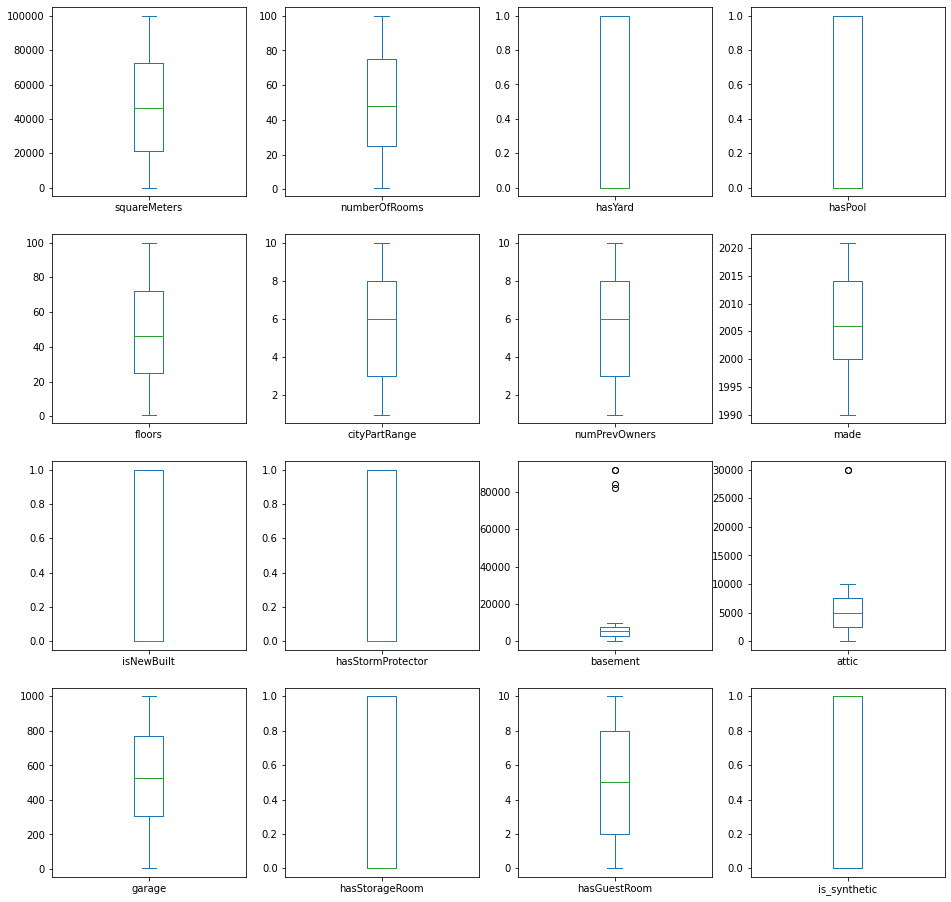

```python
# Box and Whisker plot for each attribute
df_features_train.plot(kind='box', subplots=True, layout=(display_rows, display_columns))
plt.show()
```

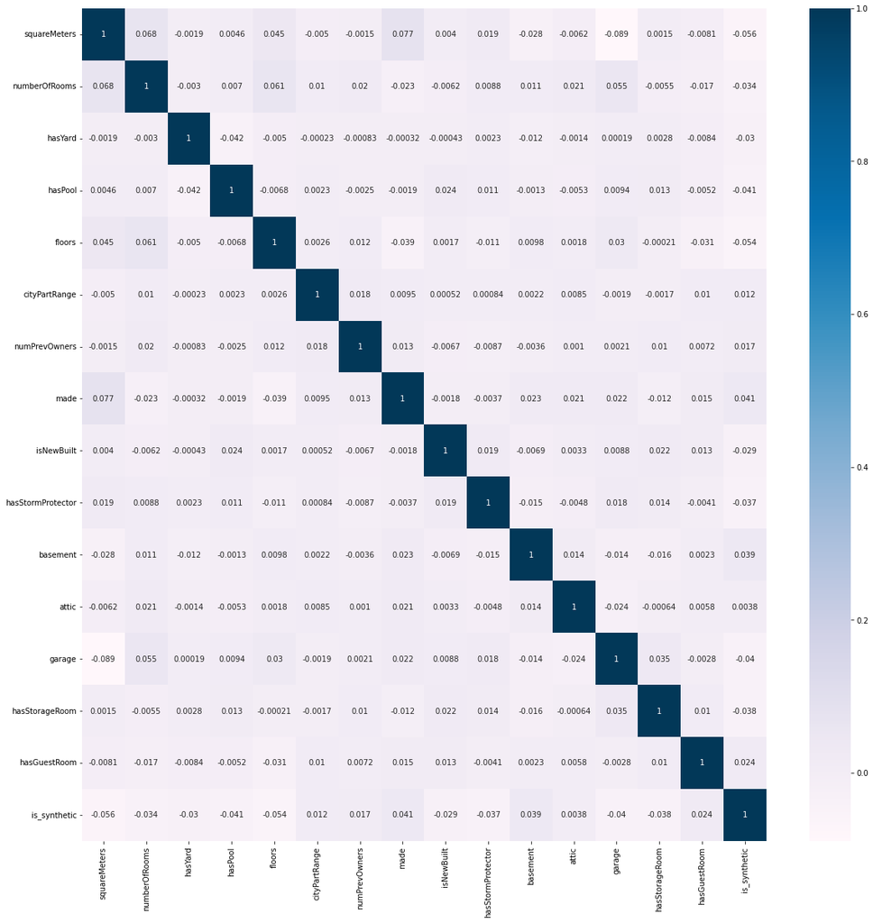

```python
# Correlation matrix
fig = plt.figure(figsize=(20, 20))
correlations = df_features_train.corr(method='pearson')
sns.heatmap(correlations, annot=True, cmap=plt.cm.PuBu)
plt.show()
```

```python
if NOTIFY_STATUS: status_notify("Task 2 - Summarize and Visualize Data completed! "+datetime.now().strftime('%a %B %d, %Y %I:%M:%S %p'))
```

## Task 3 - Train and Evaluate Models

```python
if NOTIFY_STATUS: status_notify("Task 3 - Train and Evaluate Models has begun! "+datetime.now().strftime('%a %B %d, %Y %I:%M:%S %p'))
```

### 3.a) Splitting Data into Training and Validation Sets

```python
# Finalize the training and validation datasets for the modeling activities
tfds_train = tfdf.keras.pd_dataframe_to_tf_dataset(df_dataset_import, label='target', task = tfdf.keras.Task.REGRESSION)
```

### 3.b) Train and Evaluate the Random Forest Model

```python
# Initialize the default model and get a baseline result
start_time_module = datetime.now()
tf.keras.utils.set_random_seed(RNG_SEED)
RF_model = tfdf.keras.RandomForestModel(task = tfdf.keras.Task.REGRESSION)
RF_model.compile(metrics=DEFAULT_METRICS)
RF_model.fit(x=tfds_train)
print('Total time for model fitting:', (datetime.now() - start_time_module))
```

```
Use /tmp/tmpkkkzcvp7 as temporary training directory
Reading training dataset...
```

[output not shown]

```
Training dataset read in 0:00:17.618409. Found 32715 examples.
Training model...
Model trained in 0:01:03.743846
Compiling model...
```

[output not shown]

[output not shown]

```python
RF_model.evaluate(tfds_train)
```

```
[0.0, 118614.2109375]
```

```python
RF_model.summary()
```

```
Model: "random_forest_model"
_________________________________________________________________
 Layer (type)                Output Shape              Param #
=================================================================
=================================================================
Total params: 1
Trainable params: 0
Non-trainable params: 1
_________________________________________________________________
Type: "RANDOM_FOREST"
Task: REGRESSION
Label: "__LABEL"

Input Features (16):
	attic
	basement
	cityPartRange
	floors
	garage
	hasGuestRoom
	hasPool
	hasStorageRoom
	hasStormProtector
	hasYard
	isNewBuilt
	is_synthetic
	made
	numPrevOwners
	numberOfRooms
	squareMeters

No weights

Variable Importance: INV_MEAN_MIN_DEPTH:
    1.      "squareMeters"  0.427907 ################
    2.              "made"  0.163552 ####
    3.            "garage"  0.138922 ###
    4.     "numberOfRooms"  0.110861 #
    5.            "floors"  0.103896 #
    6.          "basement"  0.100458 #
```

[output cut: 254 more lines]

```
	trees: 161, Out-of-bag evaluation: rmse:157116
	trees: 171, Out-of-bag evaluation: rmse:157082
	trees: 181, Out-of-bag evaluation: rmse:157086
	trees: 191, Out-of-bag evaluation: rmse:157170
	trees: 201, Out-of-bag evaluation: rmse:156838
	trees: 211, Out-of-bag evaluation: rmse:156523
	trees: 221, Out-of-bag evaluation: rmse:156457
	trees: 231, Out-of-bag evaluation: rmse:156277
	trees: 241, Out-of-bag evaluation: rmse:156504
	trees: 251, Out-of-bag evaluation: rmse:156588
	trees: 261, Out-of-bag evaluation: rmse:156114
	trees: 271, Out-of-bag evaluation: rmse:156183
	trees: 281, Out-of-bag evaluation: rmse:156050
	trees: 291, Out-of-bag evaluation: rmse:156070
	trees: 300, Out-of-bag evaluation: rmse:155979
```

### 3.c) Train and Evaluate the Decision Trees Model

```python
# Initialize the default model and get a baseline result
start_time_module = datetime.now()
tf.keras.utils.set_random_seed(RNG_SEED)
CART_model = tfdf.keras.CartModel(task = tfdf.keras.Task.REGRESSION)
CART_model.compile(metrics=DEFAULT_METRICS)
CART_model.fit(x=tfds_train)
print('Total time for model fitting:', (datetime.now() - start_time_module))
```

```
Use /tmp/tmpt63ub20m as temporary training directory
Reading training dataset...
Training dataset read in 0:00:01.072836. Found 32715 examples.
Training model...
Model trained in 0:00:00.217472
Compiling model...
Model compiled.
Total time for model fitting: 0:00:01.630771
```

```python
CART_model.evaluate(tfds_train)
```

```
[0.0, 195345.671875]
```

```python
CART_model.summary()
```

```
Model: "cart_model"
_________________________________________________________________
 Layer (type)                Output Shape              Param #
=================================================================
=================================================================
Total params: 1
Trainable params: 0
Non-trainable params: 1
_________________________________________________________________
Type: "RANDOM_FOREST"
Task: REGRESSION
Label: "__LABEL"

Input Features (16):
	attic
	basement
	cityPartRange
	floors
	garage
	hasGuestRoom
	hasPool
	hasStorageRoom
	hasStormProtector
	hasYard
	isNewBuilt
	is_synthetic
	made
	numPrevOwners
	numberOfRooms
	squareMeters

No weights

Variable Importance: INV_MEAN_MIN_DEPTH:
    1.      "squareMeters"  1.000000 ################
    2.            "garage"  0.205591 ##
    3.              "made"  0.122636
    4.          "basement"  0.112452
    5.             "attic"  0.111434
    6.      "hasGuestRoom"  0.096237
```

[output cut: 157 more lines]

```

Condition type in nodes:
	2301 : HigherCondition
Condition type in nodes with depth <= 0:
	1 : HigherCondition
Condition type in nodes with depth <= 1:
	3 : HigherCondition
Condition type in nodes with depth <= 2:
	7 : HigherCondition
Condition type in nodes with depth <= 3:
	15 : HigherCondition
Condition type in nodes with depth <= 5:
	61 : HigherCondition
Node format: NOT_SET
Pruned nodes during training: 2488
```

### 3.d) Train and Evaluate the Gradient Boosted Trees Model

```python
# Initialize the default model and get a baseline result
start_time_module = datetime.now()
tf.keras.utils.set_random_seed(RNG_SEED)
GBT_model = tfdf.keras.GradientBoostedTreesModel(task = tfdf.keras.Task.REGRESSION)
GBT_model.compile(metrics=DEFAULT_METRICS)
GBT_model.fit(x=tfds_train)
print('Total time for model fitting:', (datetime.now() - start_time_module))
```

```
Use /tmp/tmpup6o3adt as temporary training directory
Reading training dataset...
Training dataset read in 0:00:00.855281. Found 32715 examples.
Training model...
Model trained in 0:00:08.936197
Compiling model...
Model compiled.
Total time for model fitting: 0:00:10.658022
```

```python
GBT_model.evaluate(tfds_train)
```

```
[0.0, 176889.640625]
```

```python
GBT_model.summary()
```

```
Model: "gradient_boosted_trees_model"
_________________________________________________________________
 Layer (type)                Output Shape              Param #
=================================================================
=================================================================
Total params: 1
Trainable params: 0
Non-trainable params: 1
_________________________________________________________________
Type: "GRADIENT_BOOSTED_TREES"
Task: REGRESSION
Label: "__LABEL"

Input Features (16):
	attic
	basement
	cityPartRange
	floors
	garage
	hasGuestRoom
	hasPool
	hasStorageRoom
	hasStormProtector
	hasYard
	isNewBuilt
	is_synthetic
	made
	numPrevOwners
	numberOfRooms
	squareMeters

No weights

Variable Importance: INV_MEAN_MIN_DEPTH:
    1.  "squareMeters"  1.000000 ################
    2.      "basement"  0.168497
    3. "numPrevOwners"  0.168020
    4.        "floors"  0.167825
    5.          "made"  0.167769
    6.         "attic"  0.167509
```

[output cut: 149 more lines]

```

Training logs:
Number of iteration to final model: 43
	Iter:1 train-loss:2622609.750000 valid-loss:2646418.500000  train-rmse:2622609.750000 valid-rmse:2646418.500000
	Iter:2 train-loss:2361656.250000 valid-loss:2382275.250000  train-rmse:2361656.250000 valid-rmse:2382275.250000
	Iter:3 train-loss:2126863.250000 valid-loss:2144640.000000  train-rmse:2126863.250000 valid-rmse:2144640.000000
	Iter:4 train-loss:1915400.750000 valid-loss:1930783.750000  train-rmse:1915400.750000 valid-rmse:1930783.750000
	Iter:5 train-loss:1725393.125000 valid-loss:1738469.875000  train-rmse:1725393.125000 valid-rmse:1738469.875000
	Iter:6 train-loss:1554519.000000 valid-loss:1565230.875000  train-rmse:1554519.000000 valid-rmse:1565230.875000
	Iter:16 train-loss:561121.750000 valid-loss:550113.812500  train-rmse:561121.750000 valid-rmse:550113.812500
	Iter:26 train-loss:238978.078125 valid-loss:199560.562500  train-rmse:238978.078125 valid-rmse:199560.562500
	Iter:36 train-loss:151880.593750 valid-loss:95050.414062  train-rmse:151880.593750 valid-rmse:95050.414062
	Iter:46 train-loss:133613.875000 valid-loss:79309.046875  train-rmse:133613.875000 valid-rmse:79309.046875
	Iter:56 train-loss:124394.656250 valid-loss:88487.007812  train-rmse:124394.656250 valid-rmse:88487.007812
	Iter:66 train-loss:120065.054688 valid-loss:93784.968750  train-rmse:120065.054688 valid-rmse:93784.968750
```

```python
if NOTIFY_STATUS: status_notify("Task 4 - Train and Evaluate Models completed! "+datetime.now().strftime('%a %B %d, %Y %I:%M:%S %p'))
```

## Task 4 - Fine-tune and Improve Models

```python
if NOTIFY_STATUS: status_notify("Task 4 - Fine-tune and Improve Models has begun! "+datetime.now().strftime('%a %B %d, %Y %I:%M:%S %p'))
```

```python
# Not applicable for this iteration of modeling
```

```python
if NOTIFY_STATUS: status_notify("Task 4 - Fine-tune and Improve Models completed! "+datetime.now().strftime('%a %B %d, %Y %I:%M:%S %p'))
```

## Task 5 - Finalize Model and Present Analysis

```python
if NOTIFY_STATUS: status_notify("Task 5 - Finalize Model and Present Analysis has begun! "+datetime.now().strftime('%a %B %d, %Y %I:%M:%S %p'))
```

### 5.a) Train the Final Model

```python
# Define the baseline model for benchmarking
start_time_module = datetime.now()
tf.keras.utils.set_random_seed(RNG_SEED)
final_model = tfdf.keras.RandomForestModel(task = tfdf.keras.Task.REGRESSION)
# final_model = tfdf.keras.CartModel(task = tfdf.keras.Task.CLASSIFICATION)
# final_model = tfdf.keras.GradientBoostedTreesModel(task = tfdf.keras.Task.CLASSIFICATION)

# Optionally, add evaluation metrics.
final_model.compile(metrics=DEFAULT_METRICS)

# "sys_pipes" is optional. It enables the display of the training logs.
# with sys_pipes():
#     final_model.fit(x=tfds_train)

# Train the model.
final_model.fit(x=tfds_train)
print ('Model training time:', (datetime.now() - start_time_module), '\n')
```

```
Use /tmp/tmpgkz7dhn7 as temporary training directory
Reading training dataset...
Training dataset read in 0:00:00.890308. Found 32715 examples.
Training model...
Model trained in 0:01:01.837167
Compiling model...
Model compiled.
Model training time: 0:01:22.389430
```

```python
final_model.summary()
```

```
Model: "random_forest_model_1"
_________________________________________________________________
 Layer (type)                Output Shape              Param #
=================================================================
=================================================================
Total params: 1
Trainable params: 0
Non-trainable params: 1
_________________________________________________________________
Type: "RANDOM_FOREST"
Task: REGRESSION
Label: "__LABEL"

Input Features (16):
	attic
	basement
	cityPartRange
	floors
	garage
	hasGuestRoom
	hasPool
	hasStorageRoom
	hasStormProtector
	hasYard
	isNewBuilt
	is_synthetic
	made
	numPrevOwners
	numberOfRooms
	squareMeters

No weights

Variable Importance: INV_MEAN_MIN_DEPTH:
    1.      "squareMeters"  0.427907 ################
    2.              "made"  0.163552 ####
    3.            "garage"  0.138922 ###
    4.     "numberOfRooms"  0.110861 #
    5.            "floors"  0.103896 #
    6.          "basement"  0.100458 #
```

[output cut: 254 more lines]

[output not shown]

### 5.b) Load Test Dataset and Make Predictions

```python
df_features_test = pd.read_csv(TEST_DATASET)
df_features_test['is_synthetic'] = 1

# Take a peek at the dataframe after import
print(df_features_test.head())
```

```
      id  squareMeters  numberOfRooms  hasYard  hasPool  floors  cityCode  \
0  22730         47580             89        0        1       8     54830
1  22731         62083             38        0        0      87      8576
2  22732         90499             75        1        1      37     62454
3  22733         16354             47        1        1       9      9262
4  22734         67510              8        0        0      55     24112

   cityPartRange  numPrevOwners  made  isNewBuilt  hasStormProtector  \
0              5              3  1995           0                  0
1             10              3  1994           1                  1
2              9              6  1997           0                  1
3              6              5  2019           1                  1
4              3              7  2014           1                  1

   basement  attic  garage  hasStorageRoom  hasGuestRoom  is_synthetic
0      6885   8181     241               0             8             1
1      4601   9237     393               1             4             1
2      7454   2680     305               0             2             1
3       705   5097     122               1             5             1
4      3715   7979     401               1             9             1
```

```python
id_column_name = df_features_test.columns[0]
df_kaggle_submission = pd.DataFrame()
df_kaggle_submission[id_column_name] = df_features_test[id_column_name]
print(df_kaggle_submission.head())
```

```
      id
0  22730
1  22731
2  22732
3  22733
4  22734
```

```python
# Dropping unique identifier and unnecessary features
df_features_test.drop(columns=[id_column_name,'cityCode'], inplace=True)

# Take a peek at the dataframe after cleaning
print(df_features_test.head())
```

```
   squareMeters  numberOfRooms  hasYard  hasPool  floors  cityPartRange  \
0         47580             89        0        1       8              5
1         62083             38        0        0      87             10
2         90499             75        1        1      37              9
3         16354             47        1        1       9              6
4         67510              8        0        0      55              3

   numPrevOwners  made  isNewBuilt  hasStormProtector  basement  attic  \
0              3  1995           0                  0      6885   8181
1              3  1994           1                  1      4601   9237
2              6  1997           0                  1      7454   2680
3              5  2019           1                  1       705   5097
4              7  2014           1                  1      3715   7979

   garage  hasStorageRoom  hasGuestRoom  is_synthetic
0     241               0             8             1
1     393               1             4             1
2     305               0             2             1
3     122               1             5             1
4     401               1             9             1
```

```python
print(df_features_test.describe())
```

```
       squareMeters  numberOfRooms       hasYard       hasPool        floors  \
count  15154.000000   15154.000000  15154.000000  15154.000000  15154.000000
mean   45729.407681      47.874951      0.483371      0.445361     46.401148
std    29200.142520      28.164077      0.499740      0.497022     27.000547
min       69.000000       1.000000      0.000000      0.000000      1.000000
25%    19189.000000      25.000000      0.000000      0.000000     25.000000
50%    43802.000000      46.000000      0.000000      0.000000     44.000000
75%    70898.000000      75.000000      1.000000      1.000000     69.000000
max    99999.000000     100.000000      1.000000      1.000000    100.000000

       cityPartRange  numPrevOwners          made    isNewBuilt  \
count   15154.000000   15154.000000  15154.000000  15154.000000
mean        5.616933       5.602547   2006.225485      0.472219
std         2.727914       2.718316      8.156347      0.499244
min         1.000000       1.000000   1990.000000      0.000000
25%         3.000000       3.000000   2000.000000      0.000000
50%         6.000000       6.000000   2006.000000      0.000000
75%         8.000000       8.000000   2014.000000      1.000000
max        10.000000      10.000000   2021.000000      1.000000

       hasStormProtector      basement         attic        garage  \
count       15154.000000  15154.000000  15154.000000  15154.000000
mean            0.463442   5299.415468   5057.506599    525.091065
std             0.498678   2980.156234   2928.004147    268.504745
min             0.000000      8.000000      1.000000      8.000000
25%             0.000000   3114.000000   2567.000000    294.250000
50%             0.000000   5359.000000   5017.000000    501.000000
75%             1.000000   7739.000000   7650.750000    757.000000
max             1.000000  89016.000000  38535.000000   1000.000000

       hasStorageRoom  hasGuestRoom  is_synthetic
count    15154.000000  15154.000000       15154.0
mean         0.463178      5.095618           1.0
std          0.498659      3.049174           0.0
min          0.000000      0.000000           1.0
25%          0.000000      2.000000           1.0
50%          0.000000      5.000000           1.0
75%          1.000000      8.000000           1.0
max          1.000000     10.000000           1.0
```

```python
# Finalize the test dataset for the testing activities
tfds_test = tfdf.keras.pd_dataframe_to_tf_dataset(df_features_test, task = tfdf.keras.Task.REGRESSION)
```

```python
# Make batched predictions
test_predictions = final_model.predict(tfds_test)
print(test_predictions)
```

[output not shown]

```
[[4745713. ]
 [6251214. ]
 [9061244. ]
 ...
 [7322208.5]
 [7761113.5]
 [1803248.5]]
```

```python
df_sample_submission = pd.read_csv(SUBMISSION_TEMPLATE)
df_sample_submission.drop(columns=[id_column_name], inplace=True)
submission_header = list(df_sample_submission.columns)[0]
print(submission_header)
```

```
price
```

```python
df_kaggle_submission[submission_header] = test_predictions
print(df_kaggle_submission.head())
```

```
      id       price
0  22730  4745713.00
1  22731  6251214.00
2  22732  9061244.00
3  22733  1621503.75
4  22734  6730664.50
```

```python
submission_file = df_kaggle_submission.to_csv(header=True, index=False)
filename = SUBMISSION_FILE + datetime.now().strftime('%Y%m%d-%H%M') + '.csv'
with open(filename, 'w') as f:
    f.write(submission_file)
    print('Completed writing output file: ' + filename)
```

```
Completed writing output file: submission_decisionForests_20230313-2049.csv
```

```python
if NOTIFY_STATUS: status_notify("Task 5 - Finalize Model and Present Analysis completed! "+datetime.now().strftime('%a %B %d, %Y %I:%M:%S %p'))
```

```python
print ('Total time for the script:',(datetime.now() - start_time_script))
```

```
Total time for the script: 0:03:27.328064
```